# 157clin_clust_anals

fkeita

2018/3/22

```r
knitr::opts_chunk$set(echo = TRUE, cache = TRUE,cache.lazy = FALSE, echo=TRUE)
# source("http://bioconductor.org/biocLite.R")
require("stringr")
require("tidyverse")
require("MASS")
```

```r
# require("ggplot2")
# require("dplyr")
# require("magrittr")
require(extrafont)
loadfonts(quiet = T)

#biocLite("GEOquery")
##require(GEOquery)

set.seed("20180321")
```

## functions

```r
outputdir <- "./figs/"

ggsave2 <- function(plot, wid=9, hei=9){
  plot_name <- deparse(substitute(plot))
  file_name <- paste(outputdir,plot_name, ".png", sep = "",collapse = "")
  ggsave(filename = file_name,plot = plot,device = "png",width = wid, height = hei,dpi = 300,units = "cm")
}

ggsave2_pdf <- function(plot, wid=9, hei=9){
  plot_name <- deparse(substitute(plot))
  file_name <- paste(outputdir,plot_name, ".pdf", sep = "",collapse = "")
  ggsave(filename = file_name,plot = plot,device = "pdf",width = wid, height = hei,dpi = 300,units = "cm")
}



ggsave2_f <- function(plot,path, wid=9, hei=9){
  plot_name <- deparse(substitute(plot))
  file_name <- path
    # paste(outputdir, plot_name, ".tif", sep = "",collapse = "")
  ggsave(filename = file_name,plot = plot,device = "tiff",width = wid, height = hei,dpi = 300,units = "cm")
}

ggsave3 <- function(plot, path, wid=8.2, hei=8.2){
  #plot_name <- deparse(substitute(plot))
  plot_name <- path
  file_name <- path
  # file_name <- paste(plot_name, ".png", sep = "",collapse = "")
  ggsave(filename = file_name,plot = plot,device = "png",width = wid, height = hei,dpi = 600,units = "cm")
}

df_all_chr <- function(df){
  for (i in c(1, ncol(df))){
    df[[i]] <- as.character(df[[i]])
  }
  return(df)
}

theme_ggh <- function(font.size=10,legend.position = "none", fam = "Arial") {
  theme(axis.text.x = element_blank(),
        axis.text.y = element_blank(),
        axis.title = element_blank(),
        axis.line = element_blank(),
        axis.ticks = element_blank(),
        plot.title = element_blank(),
        panel.grid = element_blank(),
        panel.border = element_blank(),
        panel.spacing = element_blank(),
        panel.background = element_blank(),
        plot.background = element_blank(),
        plot.margin = unit(c(0,0,0,0),"cm"),
        text = element_text(family = fam ,size=font.size,lineheight = 0.7)
        # ,
        # legend.position = "none")
  )
}

inch2cm <- function(x){
  return(x/0.39370)
}
cm2inch <- function(x){
  return(0.39370*x)
}

p2cm <- function(x){
  return(as.integer(0.008466666666666667 * x))
}

cm2p <- function(x){
  return(as.integer(118.11023622047244 *x))
}

ggsave2_pptx <- function(plot, wid=9, hei=9){

  library(officer)
  library(rvg)

  plot_name <- deparse(substitute(plot))
  file_name <- paste(outputdir,plot_name, ".pptx", sep = "",collapse = "")
  plot_ed <- rvg::dml(ggobj = plot,width = wid, height = hei)

  doc <- read_pptx() %>%
    add_slide('Title and Content', 'Office Theme') %>%
    ph_with(value = "", location = ph_location_type(type = "title")) %>%
    ph_with(value = plot_ed, location = ph_location(type = "body",width = cm2inch(wid), height = cm2inch(hei),left = 2, top = 2))
  doc %>%
    print(target = file_name)
}


ggsave3_pptx <- function(plot, file_name, wid=9, hei=9){

  library(officer)
  library(rvg)

  # plot_name <- deparse(substitute(plot))
  # file_name <- paste("../figs_output/",plot_name, ".pptx", sep = "",collapse = "")
  # file_name <- paste(file_name, ".pptx", sep = "",collapse = "")
  plot_ed <- rvg::dml(ggobj = plot,width = wid, height = hei)

  doc <- read_pptx() %>%
    add_slide('Title and Content', 'Office Theme') %>%
    ph_with(value = "", location = ph_location_type(type = "title")) %>%
    ph_with(value = plot_ed, location = ph_location(type = "body",width = cm2inch(wid), height = cm2inch(hei),left = 2, top = 2))
  doc %>%
    print(target = file_name)
}



#paste and print
pp <- function(..., sep= "", rtn = FALSE){
  s <- paste(..., sep = sep)
  if(rtn){
    return(s)
  }else{
    cat(s)
  }
}

# -の表現ブレ問題
coerceNeg <- function(v){
  v <- v %>%
    str_remove_all(., "\\(") %>%
    str_remove_all(., "\\)") %>%
    str_replace(., "－", "-")
  v2 <- case_when(
    v == "+" ~ "pos",
    v == "-" ~ "neg",
    v == "ー"~ "neg",
    v == "‑" ~ "neg",
    v == "‐" ~ "neg",
    v == "–" ~ "neg",
    v == "—" ~ "neg",
    v == "―" ~ "neg",
    v == "ｰ" ~ "neg",
    v == "−" ~ "neg",
    v == "－" ~ "neg",
    T ~ NA_character_)
  return(v2)
}


showFigMkdwn <- function(path, wid =6, hei = 9){
  wid <- as.character(cm2p(wid))
  # wid <- as.character(pcnt)
  # hei <- cm2p(hei)
  # pp("![](",path, " =",wid,"x)")
  # pp("<img src=\"", filepath())
  # pp("<img src=", path, " width=\"", wid, "\"/>")
  pp("<img src=", path, " width=", wid, "/>")
  # pp("<img src=", path, " width=\"", pcnt, "%\"/>")
  # <img src="drawing.jpg" alt="drawing" width="200"/>
}
showFigMkdwn("path2hell")
```

```
## <img src=path2hell width=708/>
```

```r
get_Coefs <- function(m){
  m <-  summary(m)$coefficients %>%
  as.data.frame() %>%
  mutate(val = rownames(.),
         or = exp(`Estimate`),
           or_low =exp(`Estimate` -1.96*`Std. Error`),
           or_high = exp(`Estimate` +1.96*`Std. Error`)) %>%
  mutate(or_str = or %>%
           round(., digits = 2) %>%
           as.character(),
         or_low_str = or_low %>%
           round(., digits = 2) %>%
           as.character(),
         or_high_str = or_high %>%
           round(., digits = 2) %>%
           as.character()) %>%
  mutate(or_ci = str_c(or_str,
                       "(",
                       or_low_str,
                       "-",
                       or_high_str,
                       ")")) %>%
  mutate(p_val_str = case_when(
    `Pr(>|z|)` < 0.01 ~ "<0.01",
    `Pr(>|z|)` < 0.1 ~ as.character(round(`Pr(>|z|)`, digits = 3)),
    T ~as.character(round(`Pr(>|z|)`, digits = 2))
  ))  %>%
  dplyr::select(val,
                or_ci,
                p_val_str,
                everything())
  return(m)
}
```

```r
df <- read.csv(file = "./clst_clin2_R126.csv",header = T,sep = ",",stringsAsFactors = F)

name_tag <- df %>%
  sapply(., FUN = function(x){sum(!is.na(x))}) != 0

df <- df[,name_tag]

#colnames(df)[str_detect(colnames(df),"grade")]

write.table(x = t(df), file = "R126_clst_clin2.tsv",quote = F, sep = "\t",row.names = T, col.names = NA)
```

```r
var1 <- df$clst_result
var2 <- df$patient.days_to_birth
var2
```

```
##   [1]     NA -21318 -18768 -20187 -20011 -23587 -24963 -23435 -30082 -18109
##  [11] -21222 -23653 -16443 -25096 -21818 -24982 -29752 -31322 -25670 -25892
##  [21] -24359 -24046 -24279 -21273 -25608 -22552 -21073  -6545 -24020 -27162
##  [31] -26795 -26400 -24274 -29842 -27944 -25305 -18562 -19140 -28049 -22913
##  [41] -18951 -29511 -22968 -27411 -24328 -25061 -25503 -23380 -25370 -24189
##  [51] -25489 -27756 -22657 -18510  -9809 -23353 -17586 -21946 -22345 -16373
##  [61] -24787 -12863 -25979  -9107 -18553 -16460 -22375 -13255 -20067 -23156
##  [71] -16702 -17805 -20985 -21845 -17453 -21381 -20079 -20751 -21552 -22319
##  [81]  -6617 -27334 -14367 -18935 -20157 -19326 -21044 -24891 -20188 -15410
##  [91] -19697 -24934 -28406 -14613 -24646 -26857 -25403 -21003 -24925 -26471
## [101]  -7363 -25039 -26858 -21165 -28108  -8499 -17097 -26009 -23437  -8573
## [111] -28254 -10699 -28528 -24769 -15930 -24046 -27930 -16708 -13739 -24288
## [121] -26319 -24599 -27524 -23526 -24603  -9426 -20782 -27549 -26330 -28234
## [131] -23865 -24516 -19964 -29244 -16874 -20548 -24090 -11838 -22111 -31386
## [141] -22638 -22438 -26136 -26390 -23782 -24941 -24377 -28234 -26949 -29712
```

[output cut: 23 more lines]

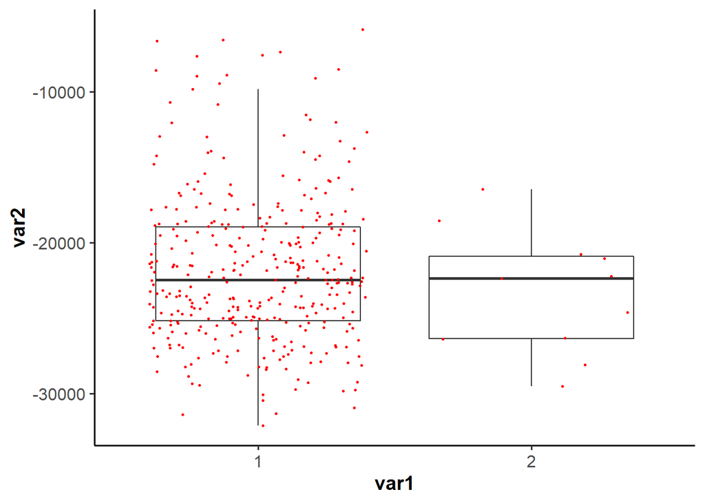

```r
gg2var <- function(var1, var2){
  require(ggplot2)

  var1_name <- deparse(substitute(var1))
  var2_name <- deparse(substitute(var2))
  df4gg <- data.frame(category = as.factor(var1), asses_var=var2)

  p1 <- ggplot()+
    geom_boxplot(data = df4gg, mapping = aes(x = category,y=asses_var),outlier.colour = NA)+
    geom_jitter(data = df4gg, mapping = aes(x = category,y=asses_var), size=0.5, color="red")+
    xlab(var1_name)+ylab(var2_name)+
    theme_classic(base_size = 14,base_family = "Arial")+
    theme(axis.text=element_text(size=12),
          axis.title=element_text(size=14,face="bold"))
  return(p1)
}

gg2var(var1, var2)
```

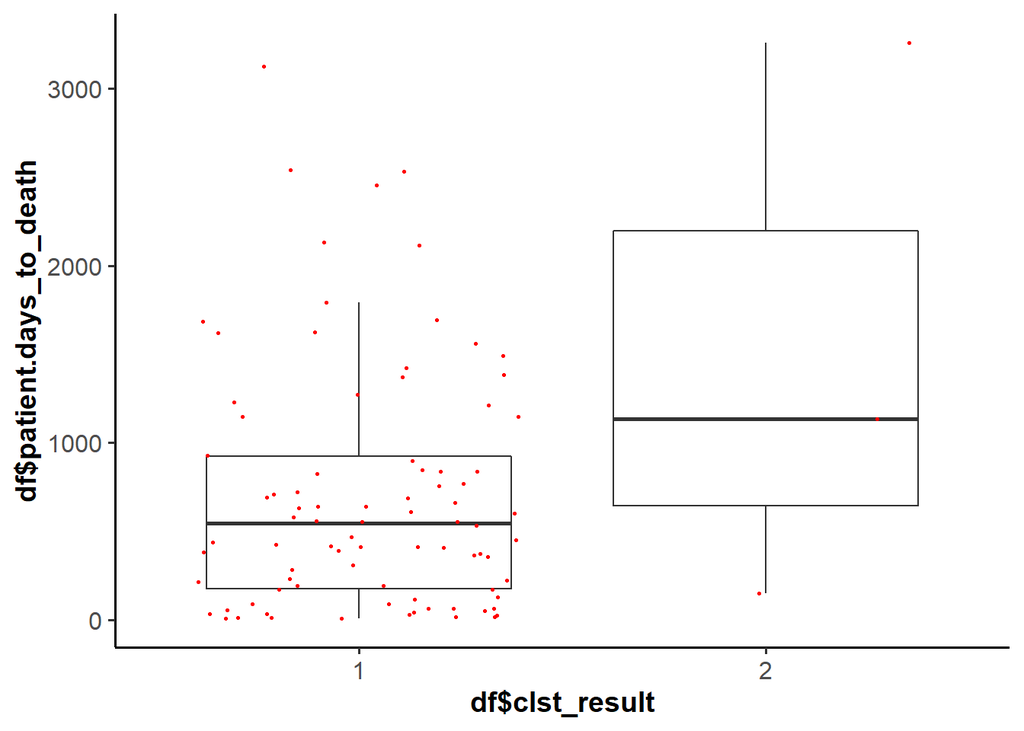

```r
gg2var(df$clst_result, df$patient.days_to_death)
```

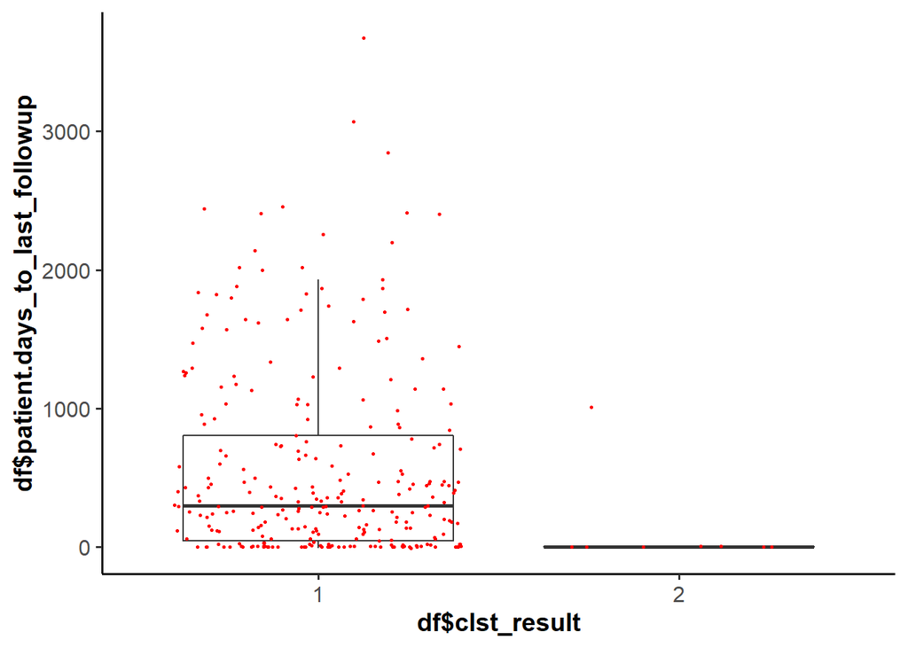

```r
gg2var(df$clst_result, df$patient.days_to_last_followup)
```

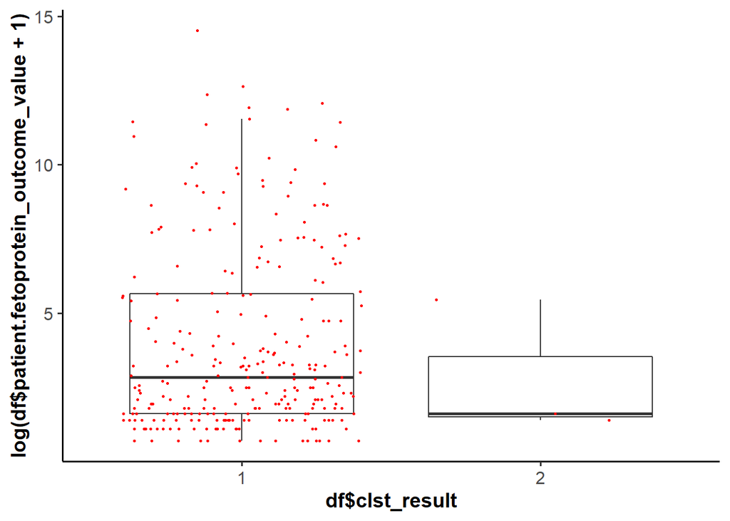

```r
gg2var(df$clst_result, log(df$patient.fetoprotein_outcome_value+1))
```

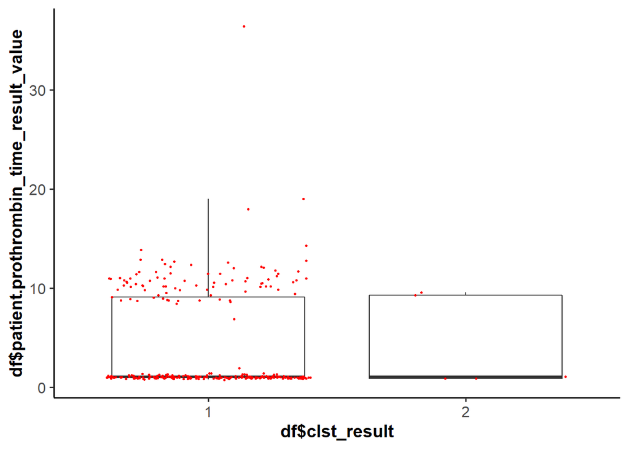

```r
gg2var(df$clst_result, df$patient.prothrombin_time_result_value)
```

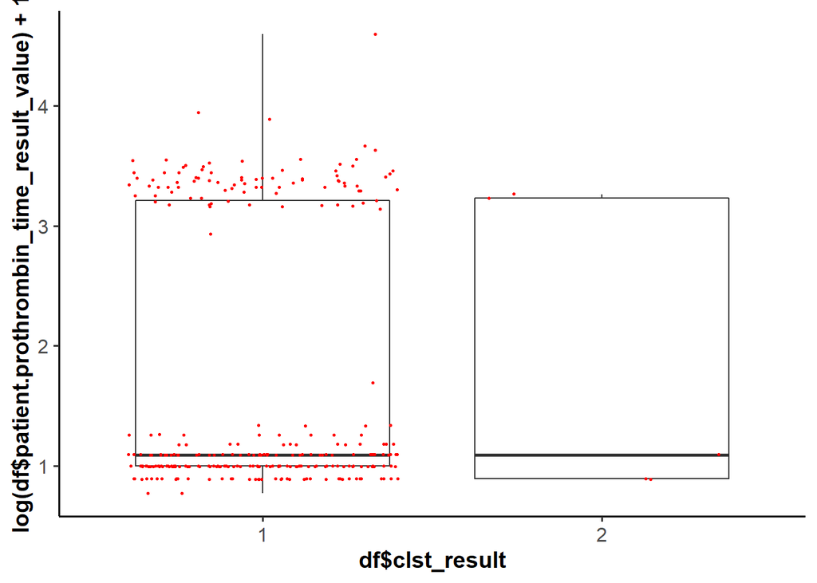

```r
gg2var(df$clst_result, log(df$patient.prothrombin_time_result_value)+1)
```

```r
table(df$clst_result, df$patient.stage_event.pathologic_stage)
```

```
##
##     stage i stage ii stage iii stage iiia stage iiib stage iiic stage iv
##   1     171       83         3         61          8          7        2
##   2       0        3         0          4          0          2        0
##
##     stage iva stage ivb
##   1         1         2
##   2         0         0
```

```r
table(df$clst_result, df$patient.gender)
```

```
##
##     female male
##   1    115  245
##   2      6    5
```

```r
table(df$clst_result, df$patient.child_pugh_classification_grade)
```

```
##
##       a   b   c
##   1 216  21   1
##   2   1   0   0
```

```r
table(df$clst_result, df$patient.histological_type)
```

```
##
##     fibrolamellar carcinoma hepatocellular carcinoma
##   1                       3                      351
##   2                       0                       10
##
##     hepatocholangiocarcinoma (mixed)
##   1                                6
##   2                                1
```

```r
table(df$clst_result, df$patient.neoplasm_histologic_grade)
```

```
##
##      g1  g2  g3  g4
##   1  54 172 118  12
##   2   1   5   4   0
```

```r
df_fac2chr <- function(df){
  df <- as.data.frame(df)
  for(i in c(1:ncol(df))){
    df[,i] <- as.character(df[,i])
  }
  return(df)
}
```

```r
#clin <- read.table(file = "./gdac.broadinstitute.org_LIHC.Merge_Clinical.Level_1.2016012800.0.0/LIHC.clin.merged.txt",header = F,sep = "\t",quote = "",stringsAsFactors = F)

clin <- read.table(file = "./gdac.broadinstitute.org_LIHC.Clinical_Pick_Tier1.Level_4.2016012800.0.0/LIHC.clin.merged.picked.txt", header = T, row.names = 1,sep = "\t",stringsAsFactors = F) %>%
  t() %>%
  df_fac2chr() %>%
  `rownames<-`(toupper(rownames(.))) %>%
  `rownames<-`(str_replace_all(rownames(.), "\\.", "\\-"))

df2 <- df %>%
  dplyr::select("Row.names", "clst_result")

dat <- merge(x = df2, y = clin, by.x="Row.names", by.y=0)

DT::datatable(data = dat, caption = "clst and clindata")
```

|  | Row.names | clst_result | Composite Element REF | years_to_birth | vital_status | days_to_death | days_to_last_followup | tumor_tissue_site | pathologic_stage | pathology_T_stage | pathology_N_stage | pathology_M_stage | gender | date_of_initial_pathologic_diagnosis | days_to_last_known_alive | radiation_therapy | histological_type | residual_tumor | race | ethnicity |
| --- | --- | --- | --- | --- | --- | --- | --- | --- | --- | --- | --- | --- | --- | --- | --- | --- | --- | --- | --- | --- |
| 1 | TCGA-2V-A95S | 1 | value |  | 0 |  |  | liver | stage ii | t2 | nx | mx | male |  |  | no | hepatocellular carcinoma | r0 | asian | not hispanic or latino |
| 2 | TCGA-2Y-A9GS | 1 | value | 58 | 1 | 724 |  | liver |  | t2 | nx | mx | male | 2006 |  | no | hepatocellular carcinoma | r0 | white | hispanic or latino |
| 3 | TCGA-2Y-A9GT | 1 | value | 51 | 1 | 1624 |  | liver | stage i | t1 | nx | mx | male | 2006 |  | no | hepatocellular carcinoma | r0 | white | not hispanic or latino |
| 4 | TCGA-2Y-A9GU | 1 | value | 55 | 0 |  | 1939 | liver | stage i | t1 | nx | mx | female | 2009 |  | no | hepatocellular carcinoma | r0 | white | not hispanic or latino |
| 5 | TCGA-2Y-A9GV | 1 | value | 54 | 1 | 2532 |  | liver | stage i | t1 | nx | mx | female | 2007 |  | no | hepatocellular carcinoma | r0 | white | not hispanic or latino |
| 6 | TCGA-2Y-A9GW | 1 | value | 64 | 1 | 1271 |  | liver | stage i | t1 | n0 | mx | male | 2007 |  | no | hepatocellular carcinoma | r0 | white | not hispanic or latino |
| 7 | TCGA-2Y-A9GX | 1 | value | 68 | 0 |  | 2442 | liver | stage i | t1 | nx | mx | male | 2007 |  | no | hepatocellular carcinoma | r1 | white | not hispanic or latino |
| 8 | TCGA-2Y-A9GY | 1 | value | 64 | 1 | 757 |  | liver | stage ii | t2 | nx | mx | female | 2007 |  | no | hepatocellular carcinoma | r0 | white | not hispanic or latino |
| 9 | TCGA-2Y-A9GZ | 1 | value | 82 | 1 | 848 |  | liver | stage ii | t2 | nx | mx | female | 2007 |  | no | hepatocellular carcinoma | r0 | white | not hispanic or latino |
| 10 | TCGA-2Y-A9H0 | 1 | value | 49 | 0 |  | 3675 | liver | stage iiia | t3 | n0 | m0 | male | 2004 |  | no | hepatocellular carcinoma | r0 | white | hispanic or latino |

[output cut: 361 more lines]

```r
dat <- dat %>%
  filter(!is.na(days_to_death) | !is.na(days_to_last_followup)) %>%
  mutate(days_to_death =
           as.numeric(ifelse(is.na(days_to_death), 0, days_to_death))) %>%
  mutate(days_to_last_followup =
           as.numeric(ifelse(is.na(days_to_last_followup), 0, days_to_last_followup))) %>%
  mutate(vital_status = as.numeric(vital_status)) %>%
  mutate(time = pmax(days_to_death, days_to_last_followup))

summary(dat)
```

```
##   Row.names          clst_result   Composite Element REF years_to_birth
##  Length:370         Min.   :1.00   Length:370            Length:370
##  Class :character   1st Qu.:1.00   Class :character      Class :character
##  Mode  :character   Median :1.00   Mode  :character      Mode  :character
##                     Mean   :1.03
##                     3rd Qu.:1.00
##                     Max.   :2.00
##   vital_status    days_to_death    days_to_last_followup tumor_tissue_site
##  Min.   :0.0000   Min.   :   0.0   Min.   :   0.0        Length:370
##  1st Qu.:0.0000   1st Qu.:   0.0   1st Qu.:   0.0        Class :character
##  Median :0.0000   Median :   0.0   Median : 377.0        Mode  :character
##  Mean   :0.3514   Mean   : 230.2   Mean   : 571.8
##  3rd Qu.:1.0000   3rd Qu.: 230.5   3rd Qu.: 807.2
##  Max.   :1.0000   Max.   :3258.0   Max.   :3675.0
##  pathologic_stage   pathology_T_stage  pathology_N_stage  pathology_M_stage
##  Length:370         Length:370         Length:370         Length:370
##  Class :character   Class :character   Class :character   Class :character
##  Mode  :character   Mode  :character   Mode  :character   Mode  :character
##
##
##
##     gender          date_of_initial_pathologic_diagnosis
##  Length:370         Length:370
##  Class :character   Class :character
##  Mode  :character   Mode  :character
##
##
##
##  days_to_last_known_alive radiation_therapy  histological_type
##  Length:370               Length:370         Length:370
##  Class :character         Class :character   Class :character
##  Mode  :character         Mode  :character   Mode  :character
##
##
##
##  residual_tumor         race            ethnicity              time
##  Length:370         Length:370         Length:370         Min.   :   0.0
##  Class :character   Class :character   Class :character   1st Qu.: 327.2
##  Mode  :character   Mode  :character   Mode  :character   Median : 587.5
##                                                           Mean   : 802.0
##                                                           3rd Qu.:1087.2
##                                                           Max.   :3675.0
```

```r
ggsave2 <- function(plot, wid=9, hei=9){
  plot_name <- deparse(substitute(plot))
  file_name <- paste(plot_name, ".tiff", sep = "",collapse = "")
  ggsave(filename = file_name,plot = plot,device = "tiff",width = wid, height = hei,dpi = 300,units = "cm")
}
```

```r
require(survival)
var <- "var"
exvar <- "clst_result"

dat <- dat %>%
  mutate(!!var := clst_result)

d.survfit <- survival::survfit(survival::Surv(time, vital_status) ~ var,
                               data = dat)
cp <- survival::coxph(survival::Surv(time, vital_status) ~ var,
                               data = dat)

summary(cp)
```

```
## Call:
## survival::coxph(formula = survival::Surv(time, vital_status) ~
##     var, data = dat)
##
##   n= 370, number of events= 130
##
##       coef exp(coef) se(coef)     z Pr(>|z|)
## var 0.5291    1.6973   0.4237 1.249    0.212
##
##     exp(coef) exp(-coef) lower .95 upper .95
## var     1.697     0.5892    0.7397     3.895
##
## Concordance= 0.512  (se = 0.011 )
## Likelihood ratio test= 1.34  on 1 df,   p=0.2
## Wald test            = 1.56  on 1 df,   p=0.2
## Score (logrank) test = 1.59  on 1 df,   p=0.2
```

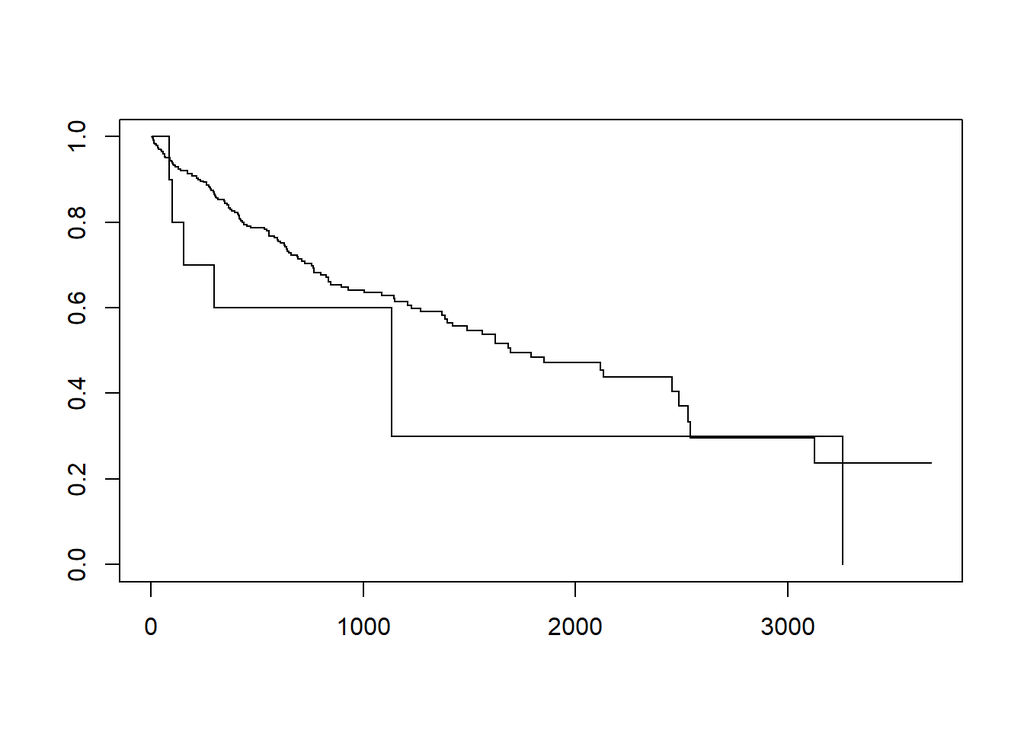

```r
plot(d.survfit)
```

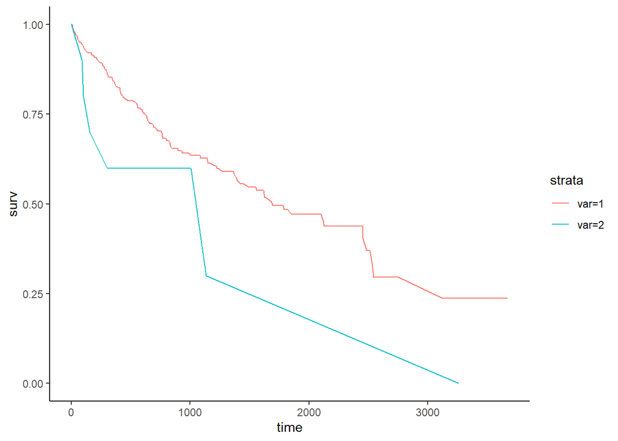

```r
fortify.survfit <- function(survfit.data) {
  data.frame(time = survfit.data$time,
             n.risk = survfit.data$n.risk,
             n.event = survfit.data$n.event,
             n.censor = survfit.data$n.censor,
             surv = survfit.data$surv,
             std.err = survfit.data$std.err,
             upper = survfit.data$upper,
             lower = survfit.data$lower,
             strata = rep(names(survfit.data$strata), survfit.data$strata))
}

svdat <- fortify.survfit(survfit.data = d.survfit)

svplot <- ggplot()+theme_classic()+
  geom_line(aes_string(x = 'time', y = 'surv', color = "strata"), data = svdat)
svplot
```

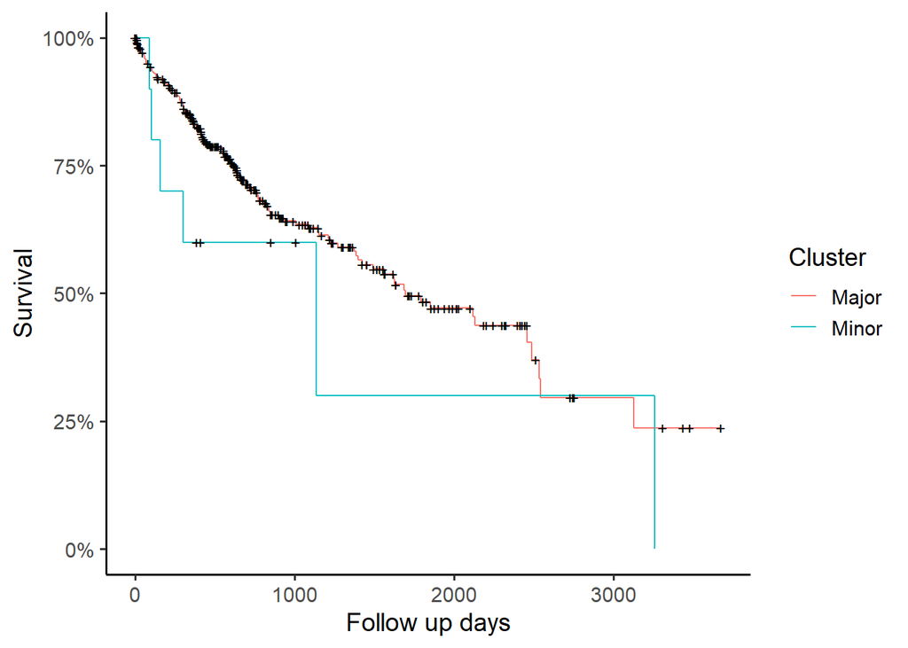

```r
ggsave2(svplot)

#install.packages('ggfortify')
require(ggfortify)
pt <- autoplot(d.survfit,conf.int = F) +theme_classic(base_size = 14,base_family = "Arial")+
  scale_color_hue(name="Cluster", labels=c("1" = "Major", "2" = "Minor"))+
  xlab("Follow up days")+ylab("Survival")
pt
```

```r
ggsave2(pt, wid = 18)
```

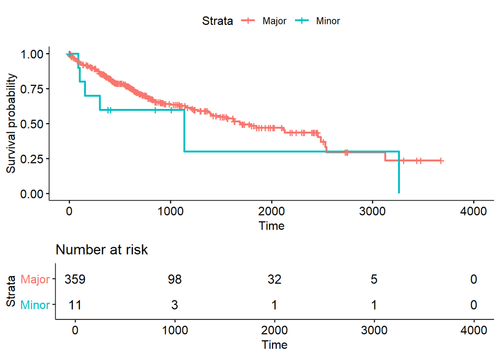

```r
# install.packages("survminer")
require("survminer")
pt_all <- ggsurvplot(d.survfit, risk.table.height = 0.25, risk.table = T,
                  ggtheme = theme_pubr(), legend.labs = c("Major", "Minor"))
# +scale_color_hue(name="Cluster", labels=c("1" = "Major", "2" = "Minor"))+
#   xlab("Follow up days")+ylab("Survival")

pt_bind <- cowplot::plot_grid(pt_all$plot,
                               pt_all$table,ncol = 1,rel_heights = c(2,1))
pt_bind
```

```r
ggsave2_f(plot = pt_bind, path = "R157_mod_pt_survival_allT.tif", wid = 12, hei=12)
```

```r
dat_t234 <- dat %>%
  mutate(pT = str_remove(pathology_T_stage, "[abc]*$") %>%
           ifelse(.=="tx", NA, .) %>%
           as.factor()) %>%
  filter(pT != "t1") %>%
  filter(!is.na(pT)) %>%
  filter(!is.na(days_to_death) | !is.na(days_to_last_followup)) %>%
  mutate(days_to_death =
           as.numeric(ifelse(is.na(days_to_death), 0, days_to_death))) %>%
  mutate(days_to_last_followup =
           as.numeric(ifelse(is.na(days_to_last_followup), 0, days_to_last_followup))) %>%
  mutate(vital_status = as.numeric(vital_status)) %>%
  mutate(time = pmax(days_to_death, days_to_last_followup)) %>%
  mutate(!!var := clst_result)

d.survfit_t234 <- survival::survfit(survival::Surv(time, vital_status) ~ var,
                               data = dat_t234)

cp_t234 <- survival::coxph(survival::Surv(time, vital_status) ~ var,
                               data = dat_t234)
summary(cp_t234)
```

```
## Call:
## survival::coxph(formula = survival::Surv(time, vital_status) ~
##     var, data = dat_t234)
##
##   n= 186, number of events= 83
##
##       coef exp(coef) se(coef)     z Pr(>|z|)
## var 0.1870    1.2057   0.4316 0.433    0.665
##
##     exp(coef) exp(-coef) lower .95 upper .95
## var     1.206     0.8294    0.5175     2.809
##
## Concordance= 0.512  (se = 0.018 )
## Likelihood ratio test= 0.18  on 1 df,   p=0.7
## Wald test            = 0.19  on 1 df,   p=0.7
## Score (logrank) test = 0.19  on 1 df,   p=0.7
```

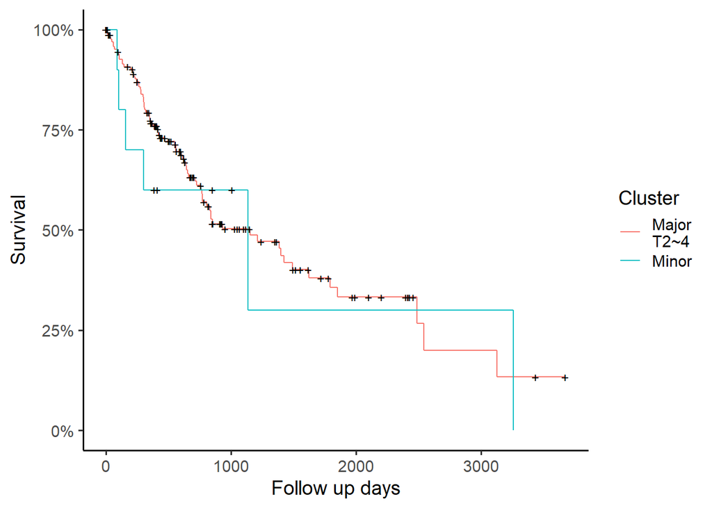

```r
pt_t234 <- autoplot(d.survfit_t234,conf.int = F) +theme_classic(base_size = 14,base_family = "Arial")+
  scale_color_hue(name="Cluster", labels=c("1" = "Major\nT2~4", "2" = "Minor"))+
  xlab("Follow up days")+ylab("Survival")
pt_t234
```

```r
# ggsave2(pt_t234, wid = 18)
```

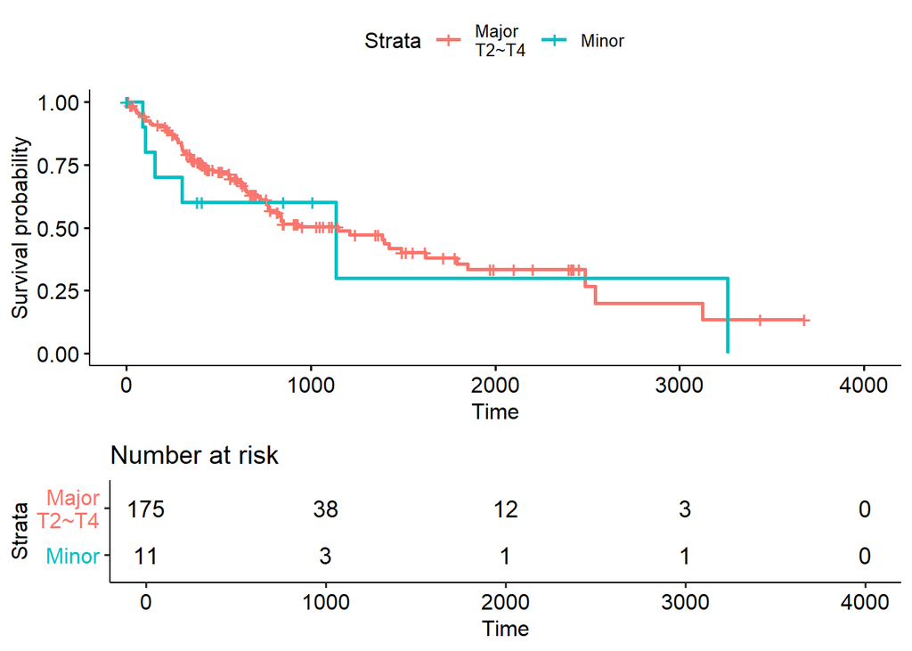

```r
# install.packages("survminer")
require("survminer")
pt2 <- ggsurvplot(d.survfit_t234, risk.table.height = 0.25, risk.table = T,
                  ggtheme = theme_pubr(), legend.labs = c("Major\nT2~T4", "Minor"))
# +scale_color_hue(name="Cluster", labels=c("1" = "Major", "2" = "Minor"))+
#   xlab("Follow up days")+ylab("Survival")

pt2_bind <- cowplot::plot_grid(pt2$plot,
                               pt2$table,ncol = 1,rel_heights = c(2,1))
pt2_bind
```

```r
ggsave2_f(plot = pt2_bind, path = "R157_mod_pt_survival.tif", wid = 12, hei=12)
```

```r
cp_zph <- cox.zph(cp)
cp_zph
```

```
##        chisq df    p
## var    0.244  1 0.62
## GLOBAL 0.244  1 0.62
```

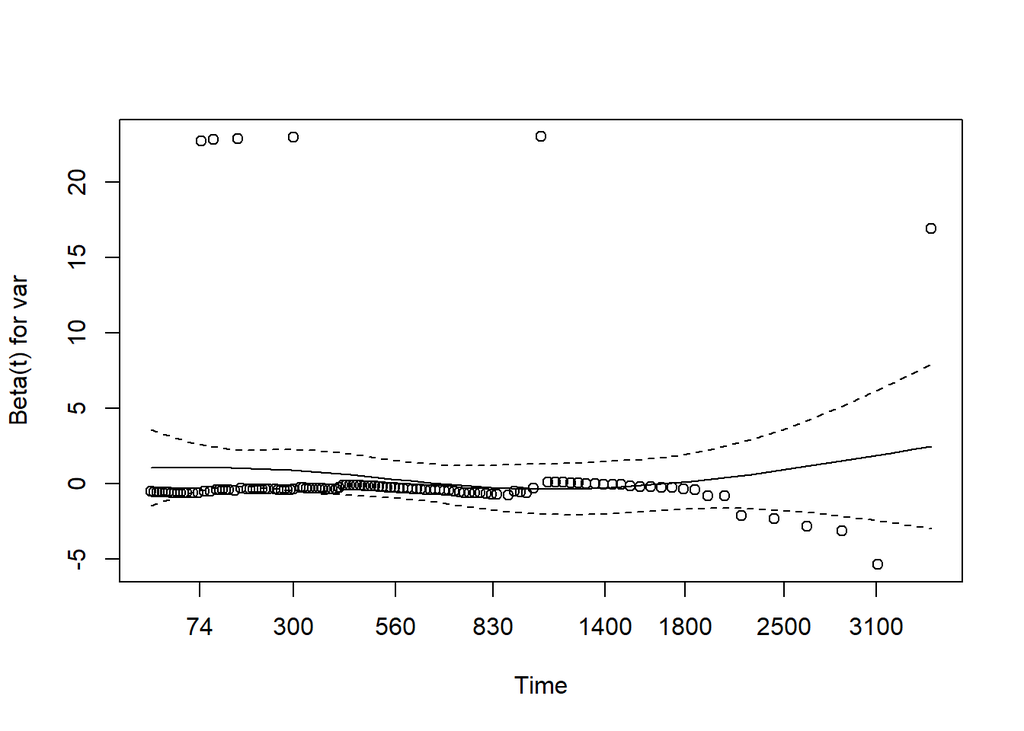

```r
plot(cp_zph)
```

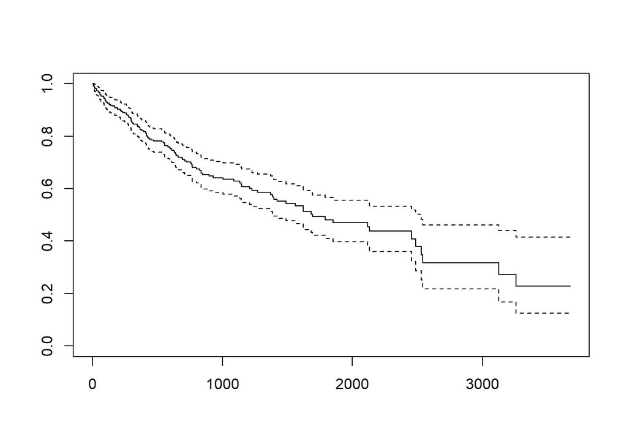

```r
km <- survfit(cp)
plot(km)
```

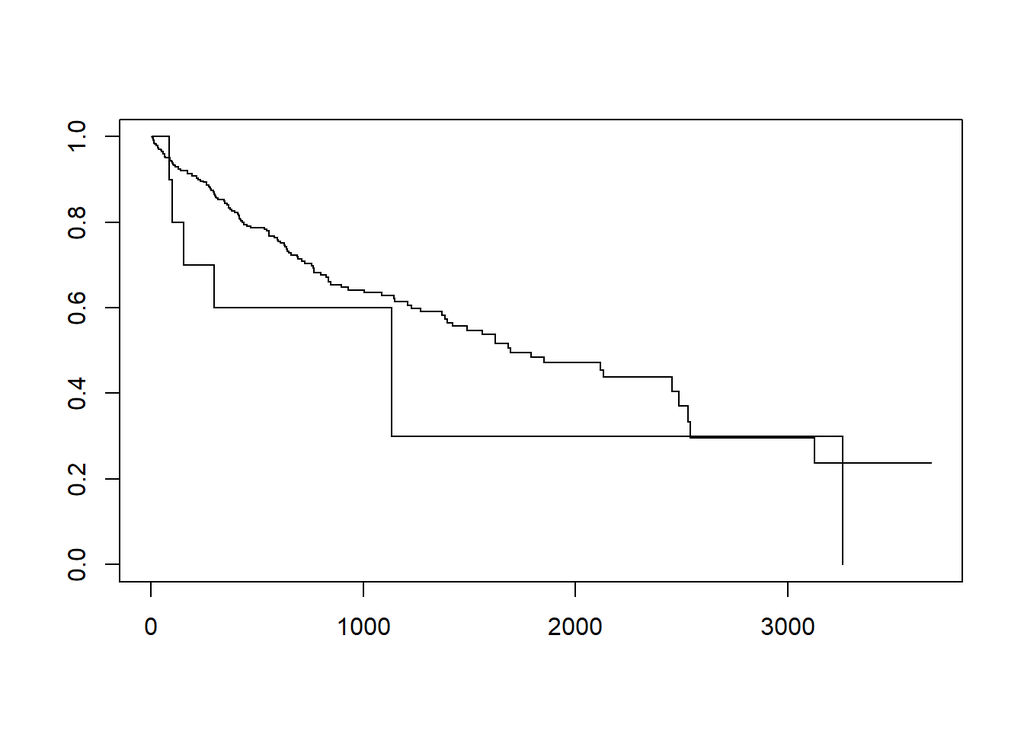

```r
km <- survival::survfit(survival::Surv(time, vital_status) ~ var,
                               data = dat)
plot(km)
```

```r
lr_km <- survdiff(survival::Surv(time, vital_status) ~ var,
                               data = dat)
lr_km
```

```
## Call:
## survdiff(formula = survival::Surv(time, vital_status) ~ var,
##     data = dat)
##
##         N Observed Expected (O-E)^2/E (O-E)^2/V
## var=1 359      124   126.35    0.0438      1.59
## var=2  11        6     3.65    1.5182      1.59
##
##  Chisq= 1.6  on 1 degrees of freedom, p= 0.2
```

```r
dat2 <- merge(x = df2, y = clin, by.x="Row.names", by.y=0) %>%
  mutate(pT = str_remove(pathology_T_stage, "[abc]*$") %>%
           ifelse(.=="tx", NA, .) %>%
           as.factor())
```

```r
clst <- "clst_result"
key <- "pathology_T_stage"
key <- "pT"

setNA2Zero <- function(vec){
  vec0 <- ifelse(is.na(vec), 0, vec)
  return(vec0)
}

setNA2Emp <- function(vec){
  vec0 <- ifelse(is.na(vec), "", vec)
  return(vec0)
}


clstInts2Strs <- function(vec){
  int2str <- function(num){
    if(num ==1){
      return("Major")
    }else if(num ==2){
      return("Minor")
    }else{
      return("Unknown")
    }
  }

  strvec <- sapply(vec, int2str)
  return(strvec)
}

#clstInts2Strs(dat$clst_result)
#clstInts2Strs(dat[[clst]])


getMat <- function(dat, clst = "clst_result", key){
  d <- dat %>%
    dplyr::filter(!is.na(.[[clst]])) %>%
    dplyr::select(one_of(c(clst, key))) %>%
    dplyr::mutate(!!clst := clstInts2Strs(.[[clst]]))

  smr <- d %>%
    mutate(count = 1) %>%
    group_by_(clst, key) %>%
    summarise(count = sum(count))

  mt <- smr %>%
    tidyr::spread_(key = key, value = "count") %>%
    purrr::map_at(.at = c(2:(ncol(.))), setNA2Zero) %>%
    as.data.frame() %>%
    `rownames<-`(.[[clst]]) %>%
    dplyr::select(-matches(clst)) %>%
    t()

  #    dplyr::select(-ends_with("NA.")) %>%

  return(mt)
}

trimLastNARow <- function(mat){
  lastname <- rownames(mat) %>%
    .[length(.)]
  if(str_detect(lastname, "NA")){
    mat <- mat %>%
      .[c(1:nrow(.) -1),]
  }else{
    print("NA row not detected.")
  }
  return(mat)
}

colnames(dat2)
```

```
##  [1] "Row.names"
##  [2] "clst_result"
##  [3] "Composite Element REF"
##  [4] "years_to_birth"
##  [5] "vital_status"
##  [6] "days_to_death"
##  [7] "days_to_last_followup"
##  [8] "tumor_tissue_site"
##  [9] "pathologic_stage"
## [10] "pathology_T_stage"
## [11] "pathology_N_stage"
## [12] "pathology_M_stage"
## [13] "gender"
## [14] "date_of_initial_pathologic_diagnosis"
## [15] "days_to_last_known_alive"
## [16] "radiation_therapy"
## [17] "histological_type"
## [18] "residual_tumor"
## [19] "race"
## [20] "ethnicity"
## [21] "pT"
```

```r
# key <- "pT"
# mat <- getMat(dat2, key = key)
#
# DT::datatable(data = mat, caption = key)
# mat <- trimLastNARow(mat)
# getChiseqFish <- function(mat){
#   print(chisq.test(mat))
#   print(fisher.test(mat))
# }
#
# getChiseqFish(mat)
```

```r
getChiseqFish <- function(mat){
  print(chisq.test(mat))
  print(fisher.test(mat))
}


checkLab_I <- function(dat, i, get_bool =F){
  key_i <- colnames(dat)[i]
  print(paste("analysing label: ", key_i, sep=""))
  mat_i <- getMat(dat, key = key_i)
  print(htmltools::tagList(
    DT::datatable(data = mat_i, caption = key_i)
  ))
  getChiseqFish(mat_i)
  #return(mat_i)
  if(get_bool){
    return(mat_i)
  }
}


# key <- colnames(dat2)[]
# mat <- getMat(dat2, key = key)
# DT::datatable(data = mat, caption = key)
# getChiseqFish(mat)
```

```r
i <- 21
cap <- colnames(dat2)[i]
mt <- checkLab_I(dat2, i,get_bool = T)
```

[1] “analysing label: pT”

[output not shown]

[output cut: 361 more lines]

```
Pearson's Chi-squared test
```

data: mat X-squared = 11.443, df = 4, p-value = 0.02201

```
Fisher's Exact Test for Count Data
```

data: mat p-value = 0.002804 alternative hypothesis: two.sided

```r
i <- 11
cap <- colnames(dat2)[i]
mt <- checkLab_I(dat2, i,get_bool = T)
```

[1] “analysing label: pathology_N_stage”

|  | Major | Minor |
| --- | --- | --- |
| n0 | 245 | 7 |
| n1 | 3 | 1 |
| nx | 111 | 3 |
| X.NA. | 1 | 0 |

```
Pearson's Chi-squared test
```

data: mat X-squared = 6.8559, df = 3, p-value = 0.07664

```
Fisher's Exact Test for Count Data
```

data: mat p-value = 0.175 alternative hypothesis: two.sided

```r
i <- 12
cap <- colnames(dat2)[i]
mt <- checkLab_I(dat2, i,get_bool = T)
```

[1] “analysing label: pathology_M_stage”

|  | Major | Minor |
| --- | --- | --- |
| m0 | 257 | 9 |
| m1 | 4 | 0 |
| mx | 99 | 2 |

```
Pearson's Chi-squared test
```

data: mat X-squared = 0.62459, df = 2, p-value = 0.7318

```
Fisher's Exact Test for Count Data
```

data: mat p-value = 0.7644 alternative hypothesis: two.sided

```r
i <- 13
cap <- colnames(dat2)[i]
mt <- checkLab_I(dat2, i,get_bool = T)
```

[1] “analysing label: gender”

|  | Major | Minor |
| --- | --- | --- |
| female | 115 | 6 |
| male | 245 | 5 |

```
Pearson's Chi-squared test with Yates' continuity correction
```

data: mat X-squared = 1.559, df = 1, p-value = 0.2118

```
Fisher's Exact Test for Count Data
```

data: mat p-value = 0.1873 alternative hypothesis: true odds ratio is not equal to 1 95 percent confidence interval: 0.09268768 1.57785868 sample estimates: odds ratio 0.3922479

```r
i <- 16
cap <- colnames(dat2)[i]
mt <- checkLab_I(dat2, i,get_bool = T)
```

[1] “analysing label: radiation_therapy”

|  | Major | Minor |
| --- | --- | --- |
| no | 329 | 10 |
| yes | 9 | 0 |
| X.NA. | 22 | 1 |

```
Pearson's Chi-squared test
```

data: mat X-squared = 0.42815, df = 2, p-value = 0.8073

```
Fisher's Exact Test for Count Data
```

data: mat p-value = 0.6345 alternative hypothesis: two.sided

```r
i <- 18
cap <- colnames(dat2)[i]
mt <- checkLab_I(dat2, i,get_bool = T)
```

[1] “analysing label: residual_tumor”

|  | Major | Minor |
| --- | --- | --- |
| r0 | 316 | 8 |
| r1 | 16 | 1 |
| r2 | 1 | 0 |
| rx | 21 | 1 |
| X.NA. | 6 | 1 |

```
Pearson's Chi-squared test
```

data: mat X-squared = 4.1195, df = 4, p-value = 0.3901

```
Fisher's Exact Test for Count Data
```

data: mat p-value = 0.1273 alternative hypothesis: two.sided

```r
i <- 19
cap <- colnames(dat2)[i]
mt <- checkLab_I(dat2, i,get_bool = T)
```

[1] “analysing label: race”

|  | Major | Minor |
| --- | --- | --- |
| american.indian.or.alaska.native | 2 | 0 |
| asian | 152 | 6 |
| black.or.african.american | 17 | 0 |
| white | 179 | 5 |
| X.NA. | 10 | 0 |

```
Pearson's Chi-squared test
```

data: mat X-squared = 1.3059, df = 4, p-value = 0.8604

```
Fisher's Exact Test for Count Data
```

data: mat p-value = 0.9033 alternative hypothesis: two.sided

```r
i <- 20
cap <- colnames(dat2)[i]
mt <- checkLab_I(dat2, i,get_bool = T)
```

[1] “analysing label: ethnicity”

|  | Major | Minor |
| --- | --- | --- |
| hispanic.or.latino | 18 | 0 |
| not.hispanic.or.latino | 323 | 11 |
| X.NA. | 19 | 0 |

```
Pearson's Chi-squared test
```

data: mat X-squared = 1.2558, df = 2, p-value = 0.5337

```
Fisher's Exact Test for Count Data
```

data: mat p-value = 1 alternative hypothesis: two.sided

```r
getI <- function(vec, i){
  return(vec[i])
}

multiRep <- function(x, pairs, unmatch = ""){
  # x
  # pairs is list of pair vector
  #stopifnot(length(pairs != 0))
  pre <- lapply(pairs, getI, i=1) %>%
    unlist()
  after <- lapply(pairs, getI, i=2) %>%
    unlist()
  ind <- match(x, pre)
  return(ifelse(is.na(ind), unmatch, after[ind]))
}

apedl <- function(l, c1, c2){
  l <- append(l, list(c(c1, c2)))
  return(l)
}

pairs <- list() %>%
  apedl("t2nxmx", "stage ii") %>%
  apedl("t1nxmx", "stage i") %>%
  apedl("t3nxmx", "stage iiia") %>%
  apedl("t4nxmx", "stage iiib") %>%
  apedl("t3anxm0", "stage iiia")


dat2 <- dat2 %>%
  mutate(pT = setNA2Emp(pathology_T_stage)) %>%
  mutate(pN = setNA2Emp(pathology_N_stage)) %>%
  mutate(pM = setNA2Emp(pathology_M_stage)) %>%
  mutate(stage4 = setNA2Emp(pathologic_stage)) %>%
  mutate(TNM = str_c(pT, pN, pM, sep="")) %>%
  mutate(stage4 = ifelse(stage4 =="",
                         multiRep(TNM, pairs = pairs),
                         stage4) %>%
           str_remove_all("stage ") %>%
           str_remove_all("[abc]*$") %>%
           ifelse(. =="", NA, .))


colnames(dat2)
```

```
##  [1] "Row.names"
##  [2] "clst_result"
##  [3] "Composite Element REF"
##  [4] "years_to_birth"
##  [5] "vital_status"
##  [6] "days_to_death"
##  [7] "days_to_last_followup"
##  [8] "tumor_tissue_site"
##  [9] "pathologic_stage"
## [10] "pathology_T_stage"
## [11] "pathology_N_stage"
## [12] "pathology_M_stage"
## [13] "gender"
## [14] "date_of_initial_pathologic_diagnosis"
## [15] "days_to_last_known_alive"
## [16] "radiation_therapy"
## [17] "histological_type"
## [18] "residual_tumor"
## [19] "race"
## [20] "ethnicity"
## [21] "pT"
## [22] "pN"
## [23] "pM"
## [24] "stage4"
## [25] "TNM"
```

```r
i <- 24
cap <- colnames(dat2)[i]
mt <- checkLab_I(dat2, i,get_bool = T)
```

[1] “analysing label: stage4”

|  | Major | Minor |
| --- | --- | --- |
| i | 179 | 0 |
| ii | 88 | 4 |
| iii | 85 | 7 |
| iv | 5 | 0 |
| X.NA. | 3 | 0 |

```
Pearson's Chi-squared test
```

data: mat X-squared = 13.221, df = 4, p-value = 0.01024

```
Fisher's Exact Test for Count Data
```

data: mat p-value = 0.003199 alternative hypothesis: two.sided

```r
Sys.time()
```

```
## [1] "2020-12-16 15:21:37 JST"
```

```r
Sys.info()
```

```
##           sysname           release           version          nodename
##         "Windows"          "10 x64"     "build 18363" "DESKTOP-I53GM5N"
##           machine             login              user    effective_user
##          "x86-64"           "areni"           "areni"           "areni"
```

##function for save attached pkgs from sessioninfo

```r
ses2ris <- function(dir="./ses_ris", ver=T){
  require("magrittr")
  require("stringr")

  if(!file.exists(dir)){
    dir.create(dir)
  }

  end_out <- function(pac, ver, dir){
    pac_ver <- packageVersion(pac)

    if(ver){
      out_file <- paste(pac, "_", pac_ver, ".ris",sep = "")
    }else{
      out_file <- paste(pac, ".ris",sep = "")
    }
    print(out_file)

    ##pac_cit <- utils:::print.bibentry(citation(pac), style = "Bibtex")
    pac_cit <- print(citation(pac),bibtex=TRUE)

    double_q <- "\""
    if(!is.na(pac_cit[1]$title)){
      pac_cit[1]$title <- str_replace(pac_cit[1]$title, "---", ":")
      pac_cit[1]$title <- str_replace_all(pac_cit[1]$title, "\\'", double_q)
    }

    capture.output(toBibtex(pac_cit),file = "tmp.bib")

    sys_code <- paste("bib2xml tmp.bib | xml2ris  > ", dir, "/", out_file, sep="")
    print(sys_code)
    system(sys_code)
  }

  pacs <- sessionInfo() %>%
    .$otherPkgs %>%
    names(.)
  print(pacs)
  sapply(X = pacs, FUN = end_out, ver=ver, dir=dir)

  file.remove("./tmp.bib")
}

ses2ris()
```

[output not shown]

[output not shown]

[output not shown]

[output not shown]

[output not shown]

[output not shown]

[output not shown]

[output not shown]

[output not shown]

[output not shown]

[output not shown]

[output not shown]

[output not shown]

[output not shown]

[output not shown]

[output not shown]

```
## [1] TRUE
```